# Clase 1 - Asignando propiedades estéticas a los datos

Diplomatura en Ciencias Sociales Computacionales

Seminario de Visualización de datos en R

Florencia Piñeyrúa, Santiago Nuñez y Nayla Sol Garcilazo

# Introducción

En este módulo vamos a trabajar con el paquete `ggplot` de R para realizar visualizaciones de datos, que forma parte del conjunto de librerías llamado `tidyverse`.

En esta clase vamos a abordar los elementos necesarios para representar un gráfico con ggplot2, haciendo foco en uno de ellos: la asignación (*mapping* en inglés) de atributos estéticos a los valores que toma una variable.

¿Cómo mostrar de modo perceptible a la vista la diferencia entre valores? Generalmente lo hacemos describiendo posiciones de un valor “x” y un valor “y”. También podemos definir un tamaño, una forma o un color.

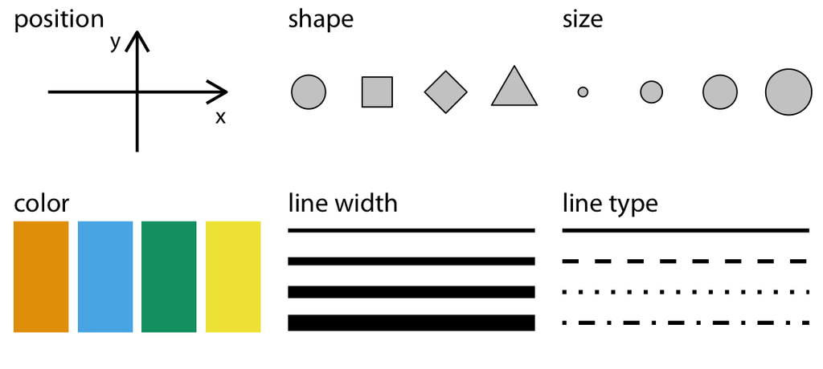

Usaremos el paquete de R [**ggplot2**](https://ggplot2.tidyverse.org/) incluye funciones para realizar una gran variedad de visualizaciones.

```r
# cargar la librería que vamos a usar
library(ggplot2)
```

Los elementos necesiarios para representar un gráfico en ggplot2 son:

1. Un data frame que contiene los datos que se quieren visualizar.
2. Los atributos estéticos (*aesthetics* en inglés) que especifica las relaciones entre variables y los atributos estéticos con los cuales se representar sus valores (como el color, el tamaño, la transparencia, la forma la línea, entre otros).
3. Los geoms que especifican los elementos geométricos, es decir, la geométria del gráfico (puntos, líneas y/o círculos).

El data set con el que practicaremos contiene la temperatura promedio para cada día del 2019 en la ciudad de Beirut, Líbano:

```r
temps_beirut
```

```
## # A tibble: 365 × 7
##    region      country city   month day_of_year  year temperature
##    <chr>       <chr>   <chr>  <ord>       <dbl> <dbl>       <dbl>
##  1 Middle East Lebanon Beirut ene             1  2019        15.7
##  2 Middle East Lebanon Beirut ene             2  2019        14.6
##  3 Middle East Lebanon Beirut ene             3  2019        14.2
##  4 Middle East Lebanon Beirut ene             4  2019        16.2
##  5 Middle East Lebanon Beirut ene             5  2019        14.9
##  6 Middle East Lebanon Beirut ene             6  2019        12.9
##  7 Middle East Lebanon Beirut ene             7  2019        11.7
##  8 Middle East Lebanon Beirut ene             8  2019        12
##  9 Middle East Lebanon Beirut ene             9  2019        12.1
## 10 Middle East Lebanon Beirut ene            10  2019        13
## # ℹ 355 more rows
```